# Scraping unstructured data

Pablo Barbera and Akitaka Matsuo

October 25, 2018

**this is an answer key with tidy coding style**

### Scraping web data in unstructured format

A common scenario for web scraping is when the data we want is available in plain html, but in different parts of the web, and not in a table format. In this scenario, we will need to find a way to extract each element, and then put it together into a data frame manually.

The motivating example here will be the website `ipaidabribe.com`, which contains a database of self-reports of bribes in India. We want to learn how much people were asked to pay for different services, and by which departments.

```r
url <- 'http://ipaidabribe.com/reports/paid'
```

We will also be using `rvest`, but in a slightly different way: prior to scraping, we need to identify the CSS selector of each element we want to extract.

A very useful tool for this purpose is `selectorGadget`, an extension to the Google Chrome browser. Go to the following website to install it: `http://selectorgadget.com/`. Now, go back to the ipaidabribe website and open the extension. Then, click on the element you want to extract, and then on the rest of highlighted elements that you do **not** want to extract. After only the elements you’re interested in are highlighted, copy and paste the CSS selector into R.

Now we’re ready to scrape the website:

```r
library(tidyverse)
library(stringi)
library(rvest)
# reading the HTML code
bribe_html <- read_html(url) # reading the HTML code
# identify the CSS selector
bribe_nodes <- html_nodes(bribe_html, css = ".paid-amount span")
# content of CSS selector
bribe_nodes
```

```
## {xml_nodeset (10)}
##  [1] <span>Paid INR 300\r\n                        </span>
##  [2] <span>Paid INR 500\r\n                        </span>
##  [3] <span>Paid INR 100\r\n                        </span>
##  [4] <span>Paid INR 100\r\n                        </span>
##  [5] <span>Paid INR 3,50,000\r\n                        </span>
##  [6] <span>Paid INR 100\r\n                        </span>
##  [7] <span>Paid INR 10,000\r\n                        </span>
##  [8] <span>Paid INR 500\r\n                        </span>
##  [9] <span>Paid INR 500\r\n                        </span>
## [10] <span>Paid INR 10\r\n                        </span>
```

We still need to do some cleaning before the data is usable:

```r
bribe_amount <- html_text(bribe_nodes) %>%
  stri_replace_first_fixed("Paid INR ", "") %>%
  stri_replace_first_regex("\\r.+", "") %>%
  stri_replace_all_fixed(",", "") %>%
  as.numeric
```

Let’s do another one: transactions during which the bribe ocurred

```r
transaction <- html_nodes(bribe_html, ".transaction a") %>% html_text
```

And one more: the department that is responsible for these transactions

```r
# and one more
dept <- html_nodes(bribe_html, ".department .name a") %>% html_text
```

This was just for one page, but note that there are many pages. How do we scrape the rest? First, following the best practices on coding, we will write a function that takes the URL of each page, scrapes it, and returns the information we want.

```r
scrape_bribe <- function(url){
  c_html <- read_html(url)
  amount <- c_html %>% html_nodes(".paid-amount span") %>%
    html_text %>%
    stri_replace_first_fixed("Paid INR ", "") %>%
    stri_replace_all_regex("\\r.+", "") %>%
    stri_replace_all_regex(",", "") %>%
    as.numeric()
  transaction <- html_nodes(c_html, ".transaction a") %>% html_text
  dept <- html_nodes(c_html, ".department .name a") %>% html_text
  df <- data.frame(amount, transaction, dept, stringsAsFactors = FALSE)
    return(df)
}
scrape_bribe(url)
```

```
##    amount                              transaction
## 1     300                                Affidavit
## 2     500         Police Verification for Passport
## 3     100      Background or Personal Verification
## 4     100                       Traffic Violations
## 5  350000            Subversion of Financial Norms
## 6     100                            Contract Work
## 7   10000 Urban Land Ceiling Clearance Certificate
## 8     500         Police Verification for Passport
## 9     500                         Berth Allocation
## 10     10                      Government Hospital
##                         dept
## 1                  Judiciary
## 2                   Passport
## 3                     Police
## 4                     Police
## 5                    Banking
## 6                   Railways
## 7                    Revenue
## 8                     Police
## 9                   Railways
## 10 Health and Family Welfare
```

And we will start a list of data frames, and put the data frame for the initial page in the first position of that list.

```r
data_list <- list(scrape_bribe(url))
```

How should we go about the following pages? Note that the following urls had `page=XX`, where `XX` is 10, 20, 30… So we will create a base url and then add these additional numbers. (Note that for this exercise we will only scrape the first 5 pages.)

```r
base_url <- "http://ipaidabribe.com/reports/paid?page="
pages <- seq(0, 40, by=10)
```

And now we just need to loop over pages, and use the function we created earlier to scrape the information, and add it to the list. Note that we’re adding a couple of seconds between HTTP requests to avoid overloading the page, as well as a message that will informs us of the progress of the loop.

```r
for (i in 2:length(pages)){
    # informative message about progress of loop
    message(i, '/', length(pages))
    # prepare URL
  url <- paste0(base_url, pages[i])
  # scrape website
    data_list[[i]] <- scrape_bribe(url)
  # wait a couple of seconds between URL calls
    Sys.sleep(2)
}
```

```
## 2/5
```

```
## 3/5
```

```
## 4/5
```

```
## 5/5
```

The final step is to convert the list of data frames into a single data frame that we can work with, using the function `do.call(rbind, LIST)` (where `LIST` is a list of data frames).

```r
## instaed of do.call, we will use bind_rows in dplyr
## which is much faster
data_all <- bind_rows(data_list)
## check
View(data_all)
```

```r
library(ggplot2)
# frequency table
summary(data_all$amount)
```

```
##    Min. 1st Qu.  Median    Mean 3rd Qu.    Max.
##      10     500    1000   60392    9500 1900000
```

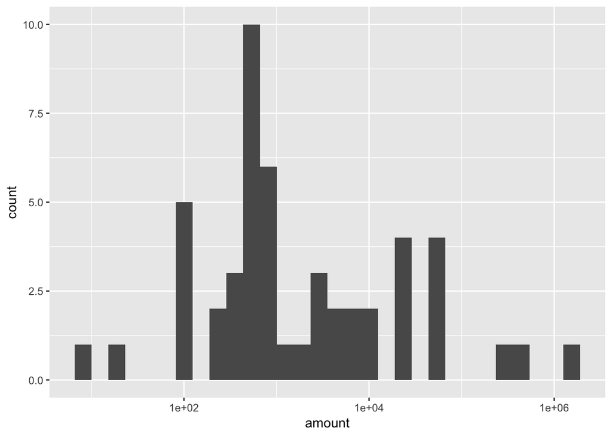

```r
# sorting the table from most to least common
ggplot(data_all, aes(x = amount)) + geom_histogram() + scale_x_log10()
```

What was the average bribe payment?

```r
mean(data_all$amount)
```

```
## [1] 60391.6
```

```r
median(data_all$amount)
```

```
## [1] 1000
```

And what was the average payment for each department?

```r
agg <- data_all %>%
  group_by(dept) %>% # group the data by department
  summarize(mean_bribe = mean(amount) %>% round(1)) %>% # get the summery statistics
  arrange(-mean_bribe) # order the data by mean bribe amount from largest to smallest
## DT will provide a sortable table in knitted document.
library(DT)
datatable(agg)
```

|  | dept | mean_bribe |
| --- | --- | --- |
| 1 | Municipal Services | 462800 |
| 2 | Banking | 117006.7 |
| 3 | Airports | 50000 |
| 4 | Others | 25750 |
| 5 | Health and Family Welfare | 25005 |
| 6 | Urban Development Authorities | 22000 |
| 7 | Electricity and Power Supply | 17866.7 |
| 8 | Revenue | 8500 |
| 9 | Stamps and Registration | 5850 |
| 10 | Transport | 5000 |

[output cut: 6 more lines]